# RNA seq experiment

load the required libraries.

```r
library(DESeq2)
library( AnnotationDbi )
library( dplyr )
library(org.Hs.eg.db)
library(msigdbr)
library(clusterProfiler)
library(tidyverse)
library(ggpubr)
library( EnhancedVolcano )
library(pheatmap)
library(pheatmap)
library(recount)
```

load the data that is required for analysis.

```r
load("ERP010786.rda")
rownames(se) <- gsub(rownames(se), pattern = "\\..+", replacement = "")
count<-assay(se)
sampleInfo<-as.data.frame(colData( se ) )
```

conduct DESeq on the data and extract the result.

```r
dds <- DESeqDataSetFromMatrix( countData = count,colData = sampleInfo,design =~condition )

dds <-DESeq( dds )

res <- results( dds )

results <- as.data.frame(res)
```

Add the the gene annotation to each of our samples and convert it into a dataframe.

```r
anno <- AnnotationDbi::select(org.Hs.eg.db, rownames(results),columns=c("ENSEMBL", "ENTREZID", "SYMBOL", "GENENAME"), keytype="ENSEMBL")

results = cbind(ENSEMBL = rownames(results), results)

anno_results <- left_join(as.data.frame(results), anno )
```

plot the volcano plot to view the genes that are differentially expressed between the samples.

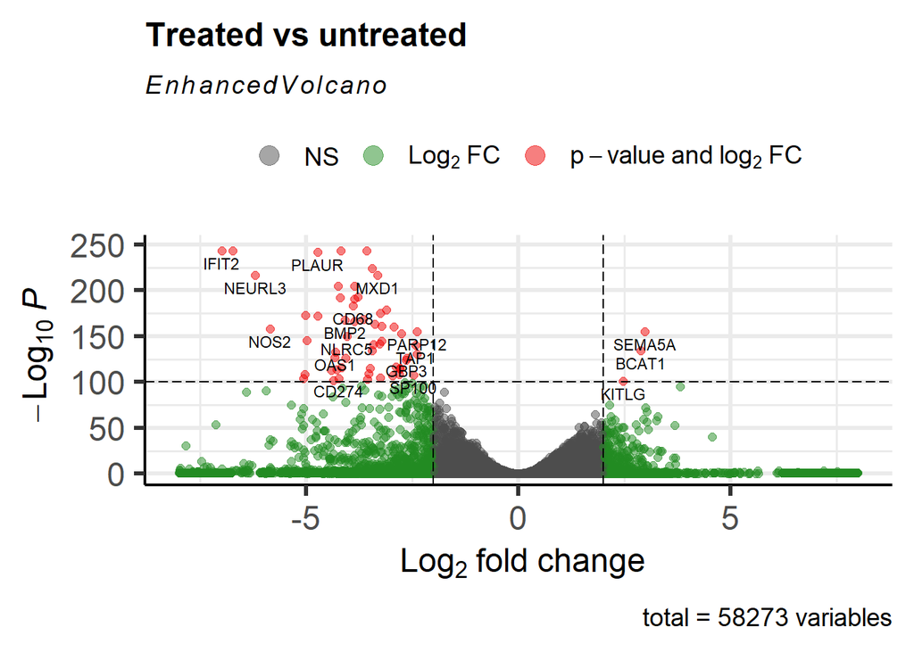

```r
EnhancedVolcano(anno_results, lab = anno_results$SYMBOL,x ='log2FoldChange', y ='padj',xlim =c(-8, 8), title ='Treated vs untreated',pCutoff = 1e-100, FCcutoff = 2, pointSize = 2.0,labSize = 3.0 )
```

perform regularised transformation on the output of the DEseq data and conduct PCA.

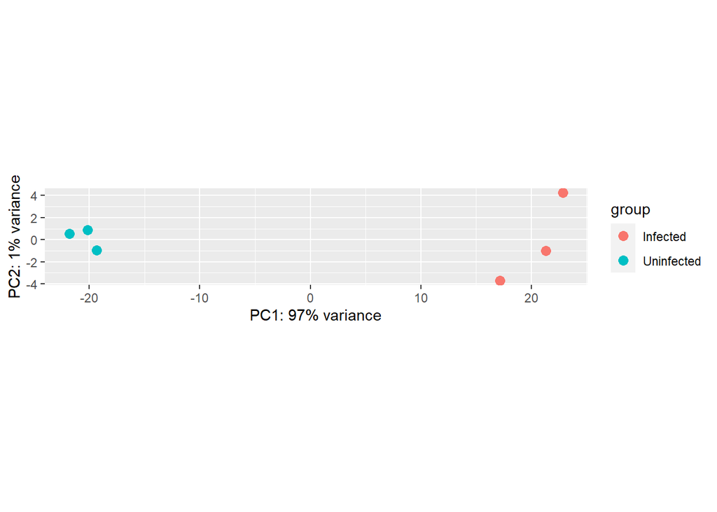

```r
rld <- rlog(dds)

plotPCA(rld, intgroup ="condition")
```

extract the significant results.

```r
resultsSig <- anno_results[which(anno_results$padj < 0.01 & abs(anno_results$log2FoldChange) >= 1 & anno_results$baseMean >= 20), ]
```

plot the heatmap with our significant results.

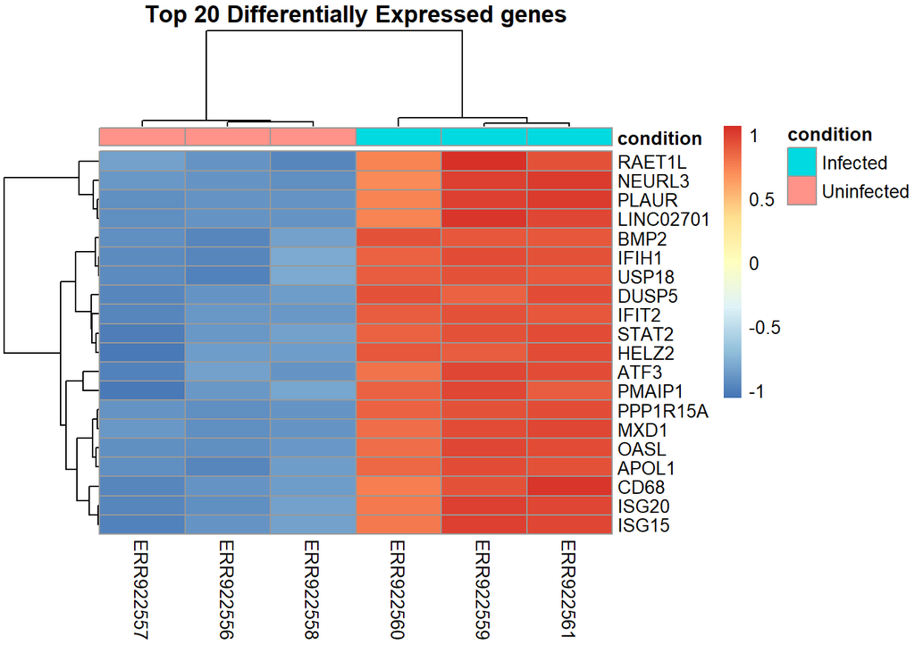

```r
mat <- assay(rld)
annotation<-data.frame("condition"=colData(rld)$condition,row.names = rownames(colData(rld)))

orderedSig <- resultsSig[order(resultsSig$padj), ]
id1 <- orderedSig$ENSEMBL
id2 <- orderedSig$SYMBOL
topDE <- mat[id1,]
rownames(topDE) <- id2
top20DE <- head(topDE, n=20)

pheatmap(top20DE, scale = "row", clustering_distance_rows = "correlation", annotation_col = annotation, main="Top 20 Differentially Expressed genes")
```

GSEA analysis :

conduct the LFC shrink for the result obtained from deseq and annotate the table.

```r
resNorm <- lfcShrink(dds = dds, res = res , type = "normal", coef = 2)


anno_norm <- AnnotationDbi::select(org.Hs.eg.db, rownames(resNorm),
                              columns=c("ENSEMBL", "ENTREZID", "SYMBOL", "GENENAME"),
                              keytype="ENSEMBL")
resNorm = cbind(ENSEMBL = rownames(resNorm), resNorm)

anno_resnorm <- left_join(as.data.frame(resNorm), anno_norm )

resdf <- as.data.frame(anno_resnorm)
```

Add the score for the GSEA.

```r
resdf2 <- resdf %>%
  arrange(padj) %>%
  mutate(gsea_metric = -log10(padj) * sign(log2FoldChange))

resdf2 <- resdf2 %>%
  mutate(padj = case_when(padj == 0 ~ .Machine$double.xmin,
                          TRUE ~ padj)) %>%
  mutate(gsea_metric = -log10(padj) * sign(log2FoldChange))

resdf2 <- resdf2 %>%
  filter(! is.na(gsea_metric)) %>%
  arrange(desc(gsea_metric))
```

plot the histogram for the GSEA value.

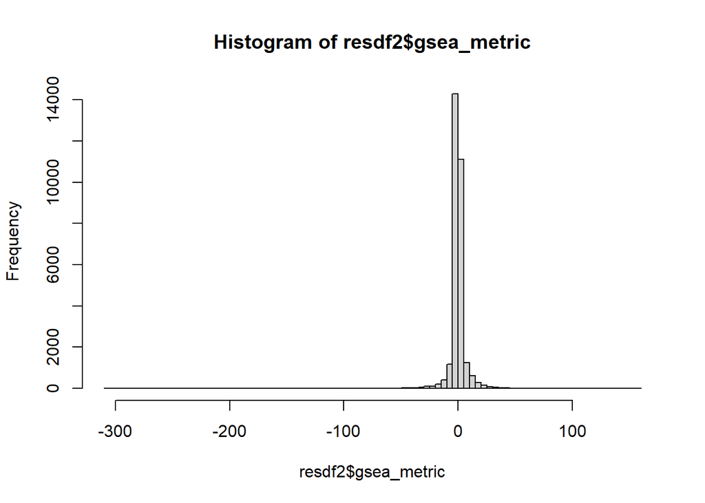

```r
hist(resdf2$gsea_metric, breaks = 100)
```

get the ranked vectors and create the gene set.

```r
ranks <- resdf2 %>%
  select(SYMBOL, gsea_metric) %>%
  distinct(SYMBOL, .keep_all = TRUE) %>%
  deframe()

gene_sets <- msigdbr(species = "Homo sapiens", category = "C5")
gene_sets <- gene_sets %>%
  dplyr::select(gs_name, gene_symbol)
```

Run GSEA and plot the pathways.

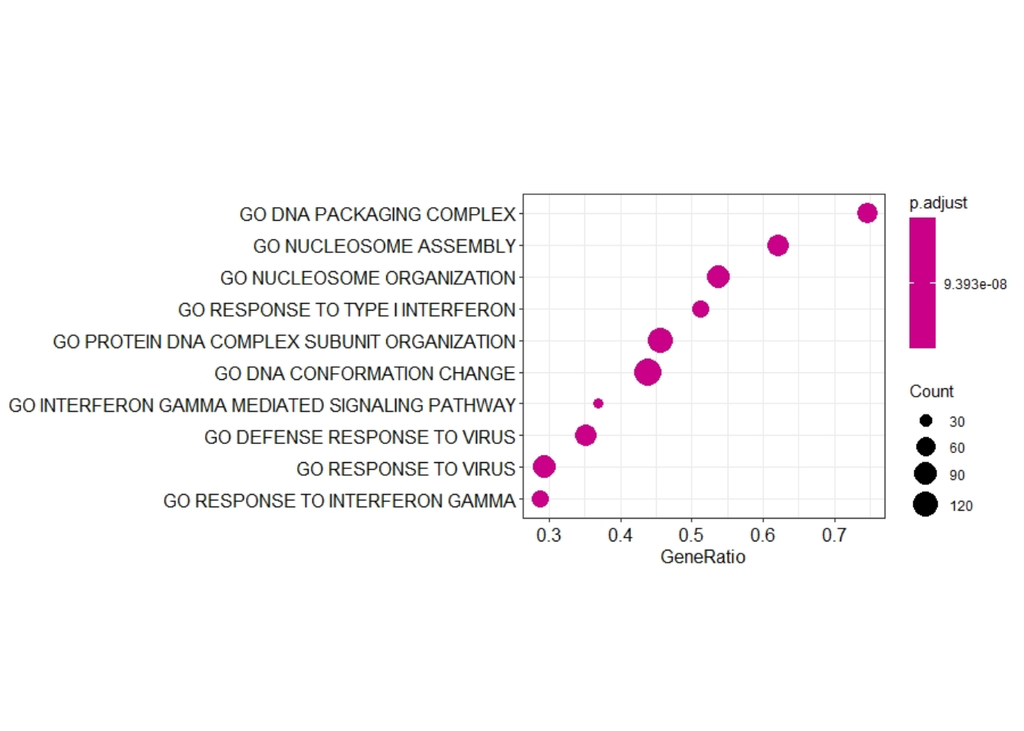

```r
gseares <- GSEA(geneList = ranks,
                TERM2GENE = gene_sets)

dotplot(gseares)
```

lets plot the top 5 upregulated pathways.

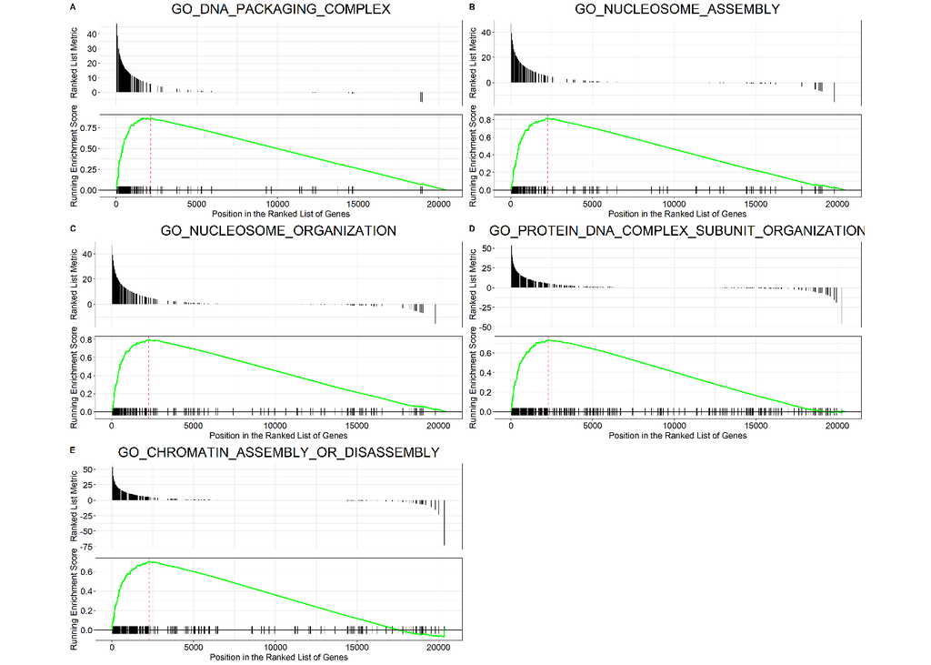

```r
gsearesdf <- as.data.frame(gseares)

top_pathways <- gsearesdf %>% top_n(n = 5, wt = NES) %>% pull(ID)

top_pathway_plots <- lapply(top_pathways, function(pathway) {
    gseaplot(gseares, geneSetID = pathway, title = pathway)
})

top_pathway_plot <- ggarrange(plotlist = top_pathway_plots, ncol = 2, nrow = 3, labels = "AUTO")
```

It is indicated that cell-cycle arrest promoted by the bacteria -induced DNA damage could increase bacterial colonisation.

The above graph shows the regulation of certain pathways that may lead to DNA damage response in the infected patients.